# Working with Data in R

Alison Hill

# Introduction

- R is an interpreter `>`
- Object-oriented `<-`
- Case matters (`i_like_snake_case`)
- Anything behind a `#` is a comment
- Packages! Install once per machine, once per R session

**Install once** per machine

```r
install.packages("tidyverse") # yes in quotes
```

**Load once** per R work session

```r
library(tidyverse) # no no quotes
```

Overriding conflicts

```r
select <- dplyr::select
```

Get help

```r
?select
```

You can also get packages that are available on GitHub (may be development versions of what is on CRAN)

```r
install.packages("devtools")
devtools::install_github("gadenbuie/ggpomological", build_vignette = TRUE)
library(ggpomological) # load like any other package
```

## RStudio

- Recommended IDE.
- Download open source desktop version: https://www.rstudio.com/products/rstudio/
- Use Projects! https://support.rstudio.com/hc/en-us/articles/200526207-Using-Projects

[figure not shown]

- Use Projects + Git in RStudio: http://happygitwithr.com

[figure not shown]

## Tidyverse

What is it? https://www.tidyverse.org

Piping/chaining with the `%>%` operator

- With the pipe, think “data frame first, data frame once”

Problem:

Nesting your dataframe in commands is hard to read

```r
head(iris)
```

```
##   Sepal.Length Sepal.Width Petal.Length Petal.Width Species
## 1          5.1         3.5          1.4         0.2  setosa
## 2          4.9         3.0          1.4         0.2  setosa
## 3          4.7         3.2          1.3         0.2  setosa
## 4          4.6         3.1          1.5         0.2  setosa
## 5          5.0         3.6          1.4         0.2  setosa
## 6          5.4         3.9          1.7         0.4  setosa
```

Solution:

Piping your dataframe into a command lets you read L to R

```r
iris %>% head(.)
```

```
##   Sepal.Length Sepal.Width Petal.Length Petal.Width Species
## 1          5.1         3.5          1.4         0.2  setosa
## 2          4.9         3.0          1.4         0.2  setosa
## 3          4.7         3.2          1.3         0.2  setosa
## 4          4.6         3.1          1.5         0.2  setosa
## 5          5.0         3.6          1.4         0.2  setosa
## 6          5.4         3.9          1.7         0.4  setosa
```

Without the pipe, sequences of commands are read inside out

```r
head(iris[iris$Species == "virginica", ])
```

```
##     Sepal.Length Sepal.Width Petal.Length Petal.Width   Species
## 101          6.3         3.3          6.0         2.5 virginica
## 102          5.8         2.7          5.1         1.9 virginica
## 103          7.1         3.0          5.9         2.1 virginica
## 104          6.3         2.9          5.6         1.8 virginica
## 105          6.5         3.0          5.8         2.2 virginica
## 106          7.6         3.0          6.6         2.1 virginica
```

Chaining your commands lets you read L to R

```r
iris %>% filter(Species == "virginica") %>% head(.)
```

```
##   Sepal.Length Sepal.Width Petal.Length Petal.Width   Species
## 1          6.3         3.3          6.0         2.5 virginica
## 2          5.8         2.7          5.1         1.9 virginica
## 3          7.1         3.0          5.9         2.1 virginica
## 4          6.3         2.9          5.6         1.8 virginica
## 5          6.5         3.0          5.8         2.2 virginica
## 6          7.6         3.0          6.6         2.1 virginica
```

# Reading data

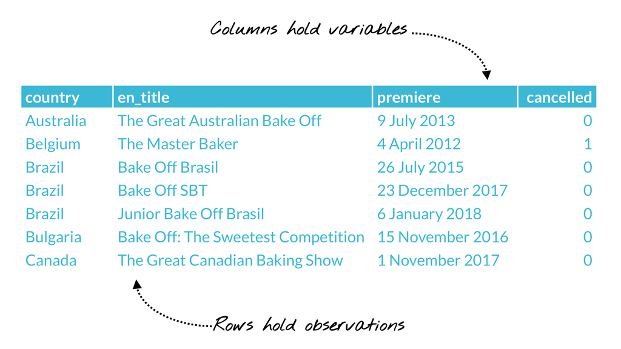

- Recommendation: `readr` package
- Loaded in the `tidyverse` bundle.
- Benefits over other base import functions:
  - Faster
  - Automated sensible defaults
  - Sensible detection of variable types

We don’t need this as it loaded in the `tidyverse` package for us but a reminder…

```r
install.packages("readr") # once per machine
library(readr) # once per work session
```

Read in from a url

Our data is stored in a gist: https://gist.github.com/kylebgorman/77ce12c9167554ade560af9d34565c11

I saved the raw url as a human-readable link.

```r
mazes <- read_csv("http://bit.ly/mazes-gist")
```

Problem: File paths are hard

Solution: Use `here::here`

```r
mazes <- read_csv("https://raw.githubusercontent.com/apreshill/ohsu-ds-programming/master/data/mazes.csv") # from readr
glimpse(mazes) # from dplyr
```

```
## Observations: 381
## Variables: 12
## $ Study.ID <chr> "CSLU-001", "CSLU-001", "CSLU-001", "CSLU-001", "CSLU-0…
## $ CA       <dbl> 5.6667, 5.6667, 5.6667, 5.6667, 6.5000, 6.5000, 6.5000,…
## $ VIQ      <dbl> 124, 124, 124, 124, 124, 124, 124, 124, 108, 108, 108, …
## $ DX       <chr> "TD", "TD", "TD", "TD", "TD", "TD", "TD", "TD", "TD", "…
## $ Activity <chr> "Conversation", "Picture Description", "Play", "Wordles…
## $ Content  <dbl> 24, 1, 21, 8, 3, 5, 8, 2, 25, 10, 2, 5, 32, 20, 13, 21,…
## $ Filler   <dbl> 31, 2, 6, 2, 10, 3, 8, 2, 21, 13, 10, 2, 12, 9, 4, 4, 1…
## $ REP      <dbl> 2, 0, 3, 0, 3, 2, 3, 0, 4, 0, 0, 0, 13, 5, 5, 6, 10, 5,…
## $ REV      <dbl> 5, 0, 8, 4, 0, 1, 2, 0, 4, 2, 1, 3, 8, 7, 2, 8, 5, 1, 4…
## $ FS       <dbl> 17, 1, 10, 4, 0, 2, 3, 2, 17, 8, 1, 2, 11, 8, 6, 7, 12,…
## $ Cued     <dbl> 36, 2, 6, 2, 10, 3, 9, 2, 29, 13, 11, 2, 14, 12, 4, 11,…
## $ Not.Cued <dbl> 50, 3, 27, 10, 13, 8, 15, 4, 38, 23, 11, 7, 42, 26, 17,…
```

Problem: Variable types are hard

Solution: Use `readr::read_csv(col_types)`

```r
mazes <- read_csv("https://raw.githubusercontent.com/apreshill/ohsu-ds-programming/master/data/mazes.csv",
                  col_types = cols(
                    DX = col_factor(levels = NULL),
                    Activity = col_factor(levels = NULL)
                    )
                  )
glimpse(mazes) # from dplyr
```

```
## Observations: 381
## Variables: 12
## $ Study.ID <chr> "CSLU-001", "CSLU-001", "CSLU-001", "CSLU-001", "CSLU-0…
## $ CA       <dbl> 5.6667, 5.6667, 5.6667, 5.6667, 6.5000, 6.5000, 6.5000,…
## $ VIQ      <dbl> 124, 124, 124, 124, 124, 124, 124, 124, 108, 108, 108, …
## $ DX       <fct> TD, TD, TD, TD, TD, TD, TD, TD, TD, TD, TD, TD, TD, TD,…
## $ Activity <fct> Conversation, Picture Description, Play, Wordless Pictu…
## $ Content  <dbl> 24, 1, 21, 8, 3, 5, 8, 2, 25, 10, 2, 5, 32, 20, 13, 21,…
## $ Filler   <dbl> 31, 2, 6, 2, 10, 3, 8, 2, 21, 13, 10, 2, 12, 9, 4, 4, 1…
## $ REP      <dbl> 2, 0, 3, 0, 3, 2, 3, 0, 4, 0, 0, 0, 13, 5, 5, 6, 10, 5,…
## $ REV      <dbl> 5, 0, 8, 4, 0, 1, 2, 0, 4, 2, 1, 3, 8, 7, 2, 8, 5, 1, 4…
## $ FS       <dbl> 17, 1, 10, 4, 0, 2, 3, 2, 17, 8, 1, 2, 11, 8, 6, 7, 12,…
## $ Cued     <dbl> 36, 2, 6, 2, 10, 3, 9, 2, 29, 13, 11, 2, 14, 12, 4, 11,…
## $ Not.Cued <dbl> 50, 3, 27, 10, 13, 8, 15, 4, 38, 23, 11, 7, 42, 26, 17,…
```

Problem: But I’m a visual person…

Solution: Use `visdat::vis_dat()`

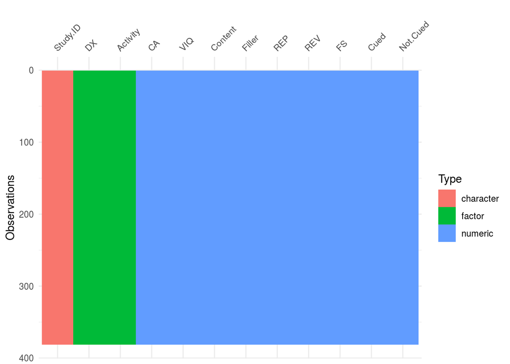

```r
library(visdat)
vis_dat(mazes)
```

Problem: Variable names are messy

Solution: Use `janitor::clean_names()`

```r
library(janitor)
mazes <- mazes %>%
  clean_names()
glimpse(mazes)
```

```
## Observations: 381
## Variables: 12
## $ study_id <chr> "CSLU-001", "CSLU-001", "CSLU-001", "CSLU-001", "CSLU-0…
## $ ca       <dbl> 5.6667, 5.6667, 5.6667, 5.6667, 6.5000, 6.5000, 6.5000,…
## $ viq      <dbl> 124, 124, 124, 124, 124, 124, 124, 124, 108, 108, 108, …
## $ dx       <fct> TD, TD, TD, TD, TD, TD, TD, TD, TD, TD, TD, TD, TD, TD,…
## $ activity <fct> Conversation, Picture Description, Play, Wordless Pictu…
## $ content  <dbl> 24, 1, 21, 8, 3, 5, 8, 2, 25, 10, 2, 5, 32, 20, 13, 21,…
## $ filler   <dbl> 31, 2, 6, 2, 10, 3, 8, 2, 21, 13, 10, 2, 12, 9, 4, 4, 1…
## $ rep      <dbl> 2, 0, 3, 0, 3, 2, 3, 0, 4, 0, 0, 0, 13, 5, 5, 6, 10, 5,…
## $ rev      <dbl> 5, 0, 8, 4, 0, 1, 2, 0, 4, 2, 1, 3, 8, 7, 2, 8, 5, 1, 4…
## $ fs       <dbl> 17, 1, 10, 4, 0, 2, 3, 2, 17, 8, 1, 2, 11, 8, 6, 7, 12,…
## $ cued     <dbl> 36, 2, 6, 2, 10, 3, 9, 2, 29, 13, 11, 2, 14, 12, 4, 11,…
## $ not_cued <dbl> 50, 3, 27, 10, 13, 8, 15, 4, 38, 23, 11, 7, 42, 26, 17,…
```

Problem: We want summary statistics for all variables with one line of code

Solution: Use `skimr::skim()`

```r
library(skimr)
skim(mazes)
```

```
## Skim summary statistics
##  n obs: 381
##  n variables: 12
##
## ── Variable type:character ────────────────────────────────────────────────────────────────────────────────────────
##  variable missing complete   n min max empty n_unique
##  study_id       0      381 381   8   8     0       97
##
## ── Variable type:factor ───────────────────────────────────────────────────────────────────────────────────────────
##  variable missing complete   n n_unique                         top_counts
##  activity       0      381 381        4 Wor: 97, Pla: 96, Con: 94, Pic: 94
##        dx       0      381 381        3  ASD: 183, TD: 127, SLI: 71, NA: 0
##  ordered
##    FALSE
##    FALSE
##
## ── Variable type:numeric ──────────────────────────────────────────────────────────────────────────────────────────
##  variable missing complete   n   mean    sd    p0   p25    p50    p75
##        ca       0      381 381   6.83  1.06  4.75  6.08   6.83   7.58
##   content       0      381 381  18.73 24.84  0     5     12     23
##      cued       0      381 381  14.36 24.22  0     2      6     15
##    filler       0      381 381  11.2  17.59  0     2      5     13
##        fs       0      381 381   8.7  12.76  0     2      5     11
##  not_cued       0      381 381  26.77 31.73  1     8     17     33
##       rep       0      381 381   6.24  9.45  0     1      3      7
##       rev       0      381 381   3.79  4.31  0     1      3      5
##       viq       0      381 381 100.82 18.74 53    85    102    116
##    p100     hist
##    8.92 ▅▆▇▇▇▇▆▂
##  214    ▇▁▁▁▁▁▁▁
##  230    ▇▁▁▁▁▁▁▁
##  152    ▇▁▁▁▁▁▁▁
##  118    ▇▁▁▁▁▁▁▁
##  222    ▇▂▁▁▁▁▁▁
##   87    ▇▁▁▁▁▁▁▁
##   37    ▇▂▁▁▁▁▁▁
##  143    ▁▁▇▇▆▅▅▂
```

Problem: We need a sanity check for our data

Solution: Count everything

```r
mazes %>% tally() # number of rows
```

```
## # A tibble: 1 x 1
##       n
##   <int>
## 1   381
```

```r
mazes %>% distinct(study_id) %>% count() # overall n
```

```
## # A tibble: 1 x 1
##       n
##   <int>
## 1    97
```

```r
mazes %>%
  summarize(n = n_distinct(study_id))
```

```
## # A tibble: 1 x 1
##       n
##   <int>
## 1    97
```

```r
mazes %>%
  count(dx, activity) # n by group/activity
```

```
## # A tibble: 12 x 3
##    dx    activity                  n
##    <fct> <fct>                 <int>
##  1 TD    Conversation             32
##  2 TD    Picture Description      31
##  3 TD    Play                     32
##  4 TD    Wordless Picture Book    32
##  5 ASD   Conversation             45
##  6 ASD   Picture Description      45
##  7 ASD   Play                     46
##  8 ASD   Wordless Picture Book    47
##  9 SLI   Conversation             17
## 10 SLI   Picture Description      18
## 11 SLI   Play                     18
## 12 SLI   Wordless Picture Book    18
```

```r
# frequency tables
mazes_tab <- mazes %>%
  tabyl(dx, activity) # from janitor package
mazes_tab
```

```
##   dx Conversation Picture Description Play Wordless Picture Book
##   TD           32                  31   32                    32
##  ASD           45                  45   46                    47
##  SLI           17                  18   18                    18
```

```r
mazes_tab %>%
  adorn_percentages("col") %>%
  adorn_pct_formatting() %>%
  adorn_ns()
```

```
##   dx Conversation Picture Description       Play Wordless Picture Book
##   TD   34.0% (32)          33.0% (31) 33.3% (32)            33.0% (32)
##  ASD   47.9% (45)          47.9% (45) 47.9% (46)            48.5% (47)
##  SLI   18.1% (17)          19.1% (18) 18.8% (18)            18.6% (18)
```

Other packages for data import in R bundled in `tidyverse`:

- `DBI`, for databases.
- `haven`, for SPSS, SAS and Stata files.
- `httr`, for web apis.
- `jsonlite` for JSON.
- `readxl`, for .xls and .xlsx files.
- `rvest`, for web scraping.
- `xml2`, for XML.

## All together now

If you can, I suggest trying to stay in the tidyverse of packages (at least to start). Recommendations:

- Use RStudio
- Use Projects within RStudio
- Use Git within Projects within RStudio
- Use `readr` to import (or other tidyverse options above)
- Use `readr` to specify column types using `col_types` argument
- Use `visdat::vis_dat()` to visualize column types
- Use `here` for file paths (hurrah!)
- Use `janitor::clean_names()` to clean up variable names
- Use `skimr` to `skim()` all the summary statistics in one line
- Use `dplyr` to count rows (yay for sanity checks)

# Taming data

Five main single-table verbs in `dplyr`:

- `select`: Choose variables/columns by their names
- `filter`: Pick rows based on conditions about their values
- `summarize`: Create summary measures of variables (or groups of observations on variables using `group_by`)
- `mutate`: Make a new variable in the data frame
- `arrange`: Sort the rows based on one or more variables

Combine with `group_by()`

http://moderndive.com/5-wrangling.html

# Tidying data

The package `tidyr` has two primary functions for tidying data:

- `gather()`
- `spread()`

[`tidyr` tidy data vignette](https://cran.r-project.org/web/packages/tidyr/vignettes/tidy-data.html)

3 rules:

- 1 variable = 1 column
- 1 observation = 1 row
- 1 value = 1 cell

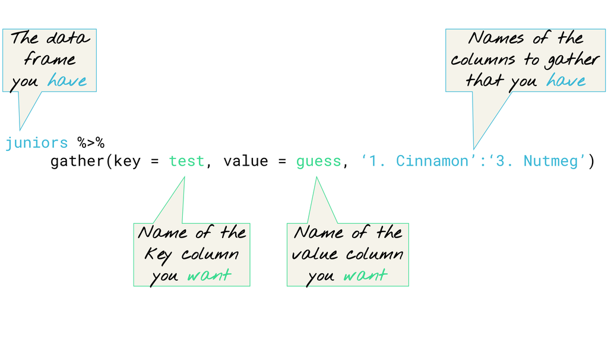

Let’s work again with the mazes data.

It is actually already tidy. Why?

```r
mazes
```

```
## # A tibble: 381 x 12
##    study_id    ca   viq dx    activity content filler   rep   rev    fs
##    <chr>    <dbl> <dbl> <fct> <fct>      <dbl>  <dbl> <dbl> <dbl> <dbl>
##  1 CSLU-001  5.67   124 TD    Convers…      24     31     2     5    17
##  2 CSLU-001  5.67   124 TD    Picture…       1      2     0     0     1
##  3 CSLU-001  5.67   124 TD    Play          21      6     3     8    10
##  4 CSLU-001  5.67   124 TD    Wordles…       8      2     0     4     4
##  5 CSLU-002  6.5    124 TD    Convers…       3     10     3     0     0
##  6 CSLU-002  6.5    124 TD    Picture…       5      3     2     1     2
##  7 CSLU-002  6.5    124 TD    Play           8      8     3     2     3
##  8 CSLU-002  6.5    124 TD    Wordles…       2      2     0     0     2
##  9 CSLU-007  7.5    108 TD    Convers…      25     21     4     4    17
## 10 CSLU-007  7.5    108 TD    Picture…      10     13     0     2     8
## # … with 371 more rows, and 2 more variables: cued <dbl>, not_cued <dbl>
```

```r
glimpse(mazes)
```

```
## Observations: 381
## Variables: 12
## $ study_id <chr> "CSLU-001", "CSLU-001", "CSLU-001", "CSLU-001", "CSLU-0…
## $ ca       <dbl> 5.6667, 5.6667, 5.6667, 5.6667, 6.5000, 6.5000, 6.5000,…
## $ viq      <dbl> 124, 124, 124, 124, 124, 124, 124, 124, 108, 108, 108, …
## $ dx       <fct> TD, TD, TD, TD, TD, TD, TD, TD, TD, TD, TD, TD, TD, TD,…
## $ activity <fct> Conversation, Picture Description, Play, Wordless Pictu…
## $ content  <dbl> 24, 1, 21, 8, 3, 5, 8, 2, 25, 10, 2, 5, 32, 20, 13, 21,…
## $ filler   <dbl> 31, 2, 6, 2, 10, 3, 8, 2, 21, 13, 10, 2, 12, 9, 4, 4, 1…
## $ rep      <dbl> 2, 0, 3, 0, 3, 2, 3, 0, 4, 0, 0, 0, 13, 5, 5, 6, 10, 5,…
## $ rev      <dbl> 5, 0, 8, 4, 0, 1, 2, 0, 4, 2, 1, 3, 8, 7, 2, 8, 5, 1, 4…
## $ fs       <dbl> 17, 1, 10, 4, 0, 2, 3, 2, 17, 8, 1, 2, 11, 8, 6, 7, 12,…
## $ cued     <dbl> 36, 2, 6, 2, 10, 3, 9, 2, 29, 13, 11, 2, 14, 12, 4, 11,…
## $ not_cued <dbl> 50, 3, 27, 10, 13, 8, 15, 4, 38, 23, 11, 7, 42, 26, 17,…
```

It could have been seriously un-tidy…

```
## # A tibble: 2,667 x 7
##    study_id    ca   viq dx    activity             variable_type maze_count
##    <chr>    <dbl> <dbl> <fct> <fct>                <chr>              <dbl>
##  1 CSLU-001  5.67   124 TD    Conversation         content               24
##  2 CSLU-001  5.67   124 TD    Picture Description  content                1
##  3 CSLU-001  5.67   124 TD    Play                 content               21
##  4 CSLU-001  5.67   124 TD    Wordless Picture Bo… content                8
##  5 CSLU-002  6.5    124 TD    Conversation         content                3
##  6 CSLU-002  6.5    124 TD    Picture Description  content                5
##  7 CSLU-002  6.5    124 TD    Play                 content                8
##  8 CSLU-002  6.5    124 TD    Wordless Picture Bo… content                2
##  9 CSLU-007  7.5    108 TD    Conversation         content               25
## 10 CSLU-007  7.5    108 TD    Picture Description  content               10
## # … with 2,657 more rows
```

```
## Observations: 97
## Variables: 32
## $ study_id                         <chr> "CSLU-001", "CSLU-002", "CSLU-0…
## $ ca                               <dbl> 5.6667, 6.5000, 7.5000, 5.2500,…
## $ viq                              <dbl> 124, 124, 108, 112, 102, 102, 8…
## $ dx                               <fct> TD, TD, TD, TD, ASD, TD, ASD, T…
## $ Conversation_content             <dbl> 24, 3, 25, 32, 27, 60, 30, 27, …
## $ Conversation_cued                <dbl> 36, 10, 29, 14, 17, 27, 7, 24, …
## $ Conversation_filler              <dbl> 31, 10, 21, 12, 12, 23, 6, 18, …
## $ Conversation_fs                  <dbl> 17, 0, 17, 11, 12, 21, 9, 16, 1…
## $ Conversation_not_cued            <dbl> 50, 13, 38, 42, 34, 79, 35, 39,…
## $ Conversation_rep                 <dbl> 2, 3, 4, 13, 10, 20, 17, 4, 5, …
## $ Conversation_rev                 <dbl> 5, 0, 4, 8, 5, 19, 4, 7, 1, 10,…
## $ `Picture Description_content`    <dbl> 1, 5, 10, 20, 9, 36, 21, 4, NA,…
## $ `Picture Description_cued`       <dbl> 2, 3, 13, 12, 7, 11, 2, 5, NA, …
```

[output cut: 19 more lines]

How could we have fixed this?

```r
mazes_step1 <- mazes_widest %>%
  gather(variable_name, maze_count, -c(study_id, ca, viq, dx))
mazes_step1
```

```
## # A tibble: 2,716 x 6
##    study_id    ca   viq dx    variable_name        maze_count
##    <chr>    <dbl> <dbl> <fct> <chr>                     <dbl>
##  1 CSLU-001  5.67   124 TD    Conversation_content         24
##  2 CSLU-002  6.5    124 TD    Conversation_content          3
##  3 CSLU-007  7.5    108 TD    Conversation_content         25
##  4 CSLU-010  5.25   112 TD    Conversation_content         32
##  5 CSLU-020  8.25   102 ASD   Conversation_content         27
##  6 CSLU-024  6.67   102 TD    Conversation_content         60
##  7 CSLU-027  8.17    81 ASD   Conversation_content         30
##  8 CSLU-031  5.67   143 TD    Conversation_content         27
##  9 CSLU-036  6.17    77 ASD   Conversation_content          7
## 10 CSLU-046  5.25   129 ASD   Conversation_content         36
## # … with 2,706 more rows
```

```r
mazes_step2 <- mazes_step1 %>%
  separate(variable_name, into = c("activity", "var_type"), sep = "_")
mazes_step2
```

```
## # A tibble: 2,716 x 7
##    study_id    ca   viq dx    activity     var_type maze_count
##    <chr>    <dbl> <dbl> <fct> <chr>        <chr>         <dbl>
##  1 CSLU-001  5.67   124 TD    Conversation content          24
##  2 CSLU-002  6.5    124 TD    Conversation content           3
##  3 CSLU-007  7.5    108 TD    Conversation content          25
##  4 CSLU-010  5.25   112 TD    Conversation content          32
##  5 CSLU-020  8.25   102 ASD   Conversation content          27
##  6 CSLU-024  6.67   102 TD    Conversation content          60
##  7 CSLU-027  8.17    81 ASD   Conversation content          30
##  8 CSLU-031  5.67   143 TD    Conversation content          27
##  9 CSLU-036  6.17    77 ASD   Conversation content           7
## 10 CSLU-046  5.25   129 ASD   Conversation content          36
## # … with 2,706 more rows
```

```r
mazes_step3 <- mazes_step2 %>%
  spread(var_type, maze_count)
mazes_step3
```

```
## # A tibble: 388 x 12
##    study_id    ca   viq dx    activity content  cued filler    fs   not
##    <chr>    <dbl> <dbl> <fct> <chr>      <dbl> <dbl>  <dbl> <dbl> <dbl>
##  1 CSLU-001  5.67   124 TD    Convers…      24    36     31    17    50
##  2 CSLU-001  5.67   124 TD    Picture…       1     2      2     1     3
##  3 CSLU-001  5.67   124 TD    Play          21     6      6    10    27
##  4 CSLU-001  5.67   124 TD    Wordles…       8     2      2     4    10
##  5 CSLU-002  6.5    124 TD    Convers…       3    10     10     0    13
##  6 CSLU-002  6.5    124 TD    Picture…       5     3      3     2     8
##  7 CSLU-002  6.5    124 TD    Play           8     9      8     3    15
##  8 CSLU-002  6.5    124 TD    Wordles…       2     2      2     2     4
##  9 CSLU-007  7.5    108 TD    Convers…      25    29     21    17    38
## 10 CSLU-007  7.5    108 TD    Picture…      10    13     13     8    23
## # … with 378 more rows, and 2 more variables: rep <dbl>, rev <dbl>
```

# Visualizing data

## Scatterplots

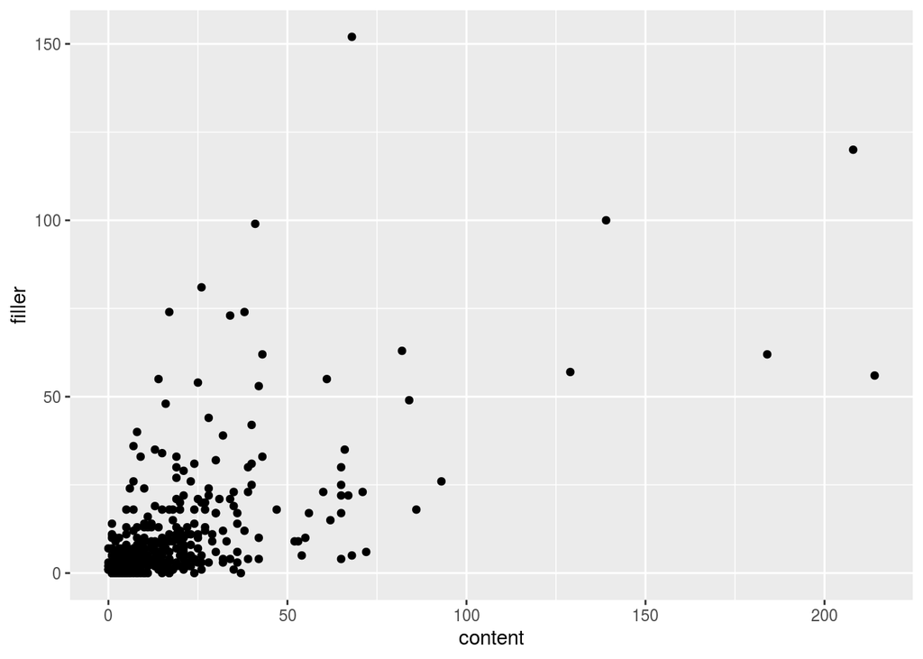

```r
(plot <- ggplot(mazes, aes(x = content, y = filler)) +
  geom_point())
```

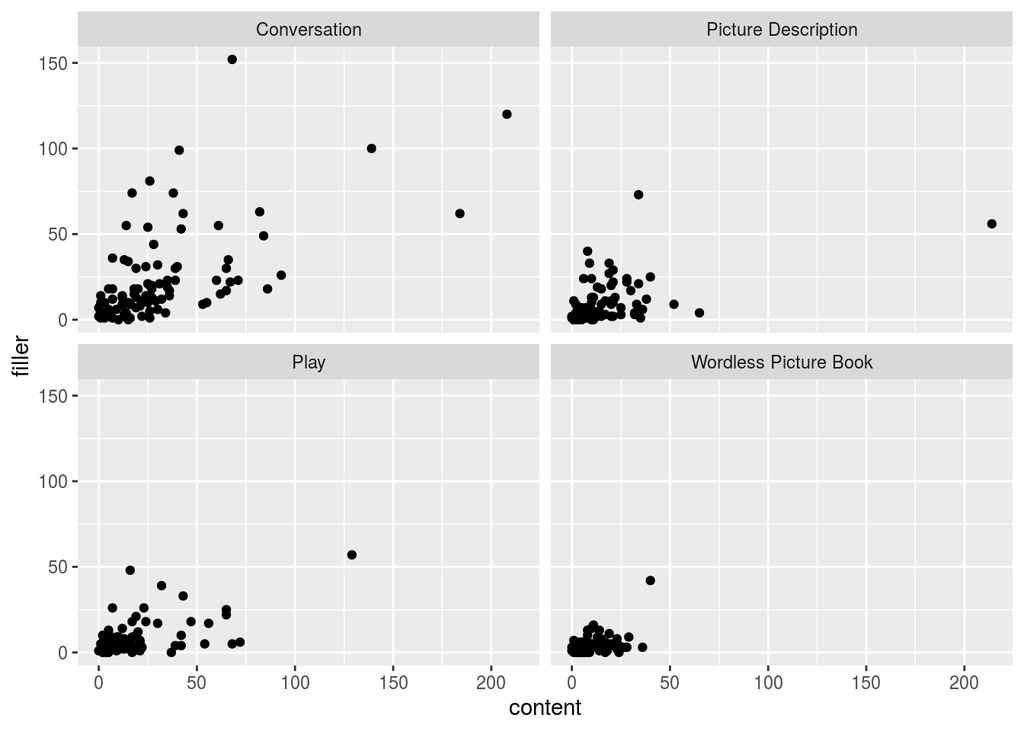

```r
(plot +
  facet_wrap(~activity))
```

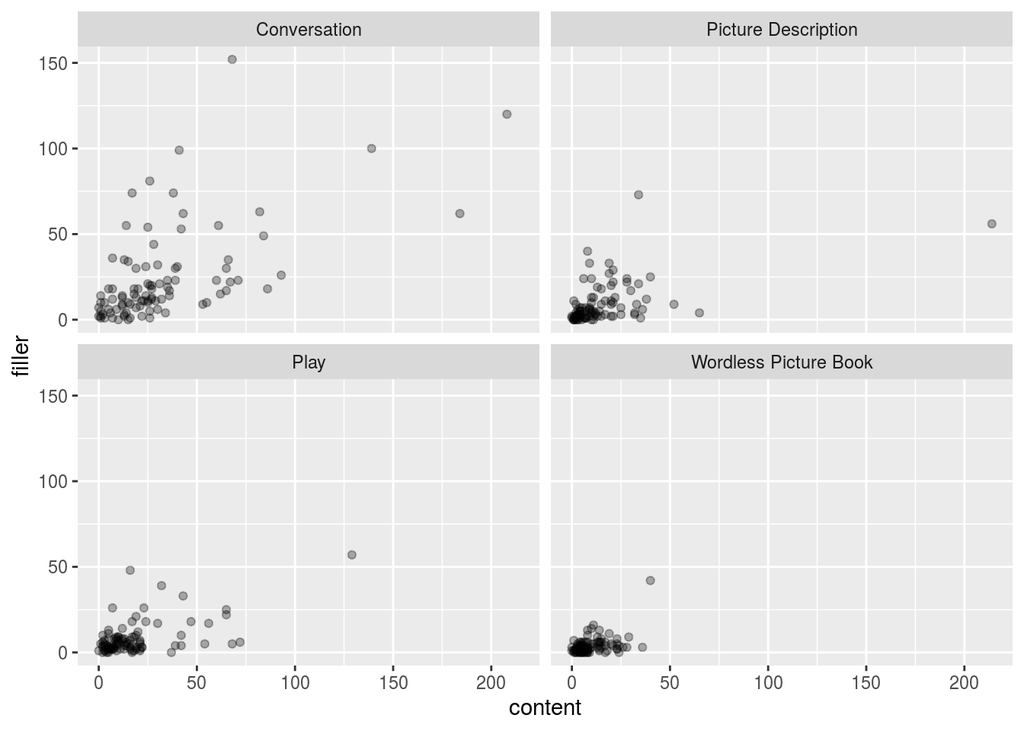

```r
plot <- ggplot(mazes, aes(x = content, y = filler)) +
  geom_point(alpha = .3) +
  facet_wrap(~activity)
plot
```

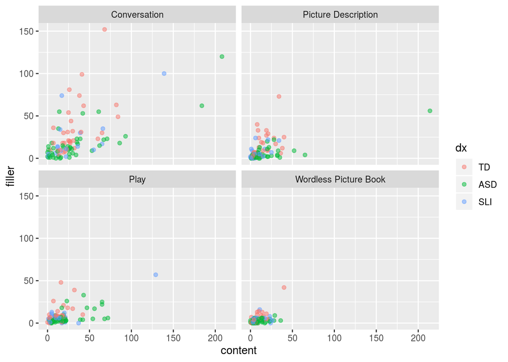

```r
plot <- ggplot(mazes, aes(x = content, y = filler, color = dx)) +
  geom_point(alpha = .5) +
  facet_wrap(~activity)
plot
```

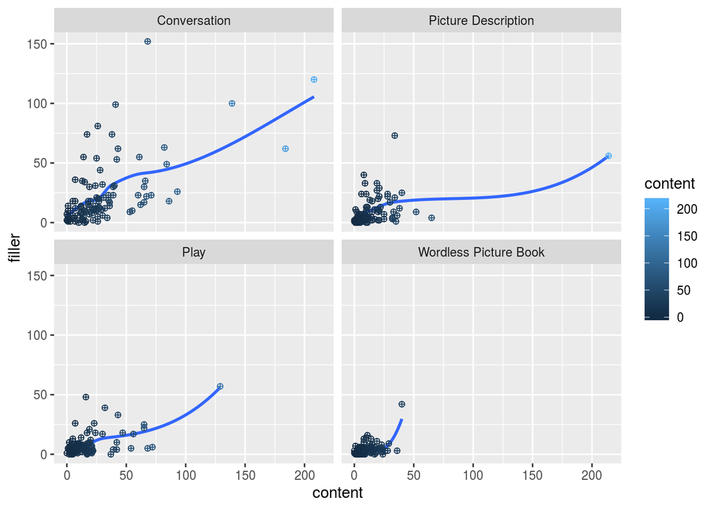

```r
plot <- ggplot(mazes, aes(x = content, y = filler)) +
  geom_smooth(se = FALSE) +
  geom_point(aes(color = content), shape = 10) +
  facet_wrap(~activity)

plot
```

Challenge!

- Try to change the lines to use the linear model (`lm`) as the smoothing method (function) to use.
- Remove color from the global aesthetics and add `geom_point(aes(color = dx), alpha = .5)`. What changes?

## Distributions

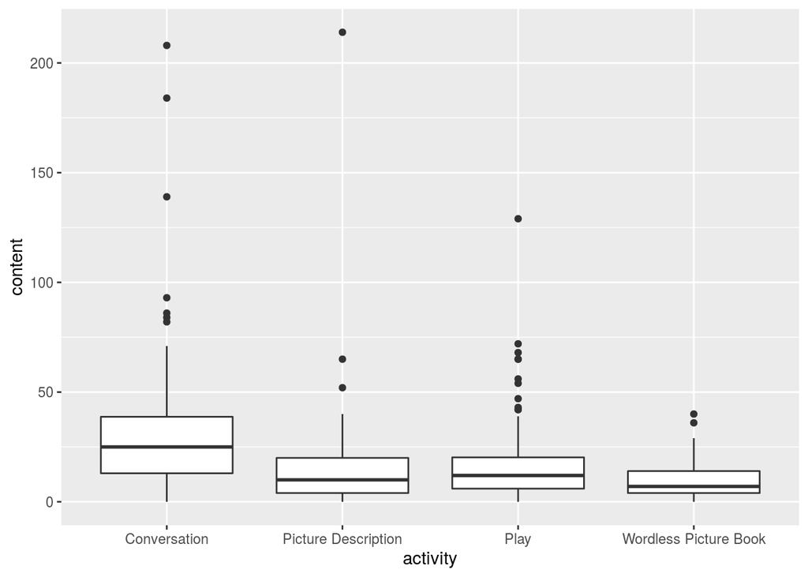

```r
ggplot(mazes, aes(x = activity, y = content)) +
  geom_boxplot()
```

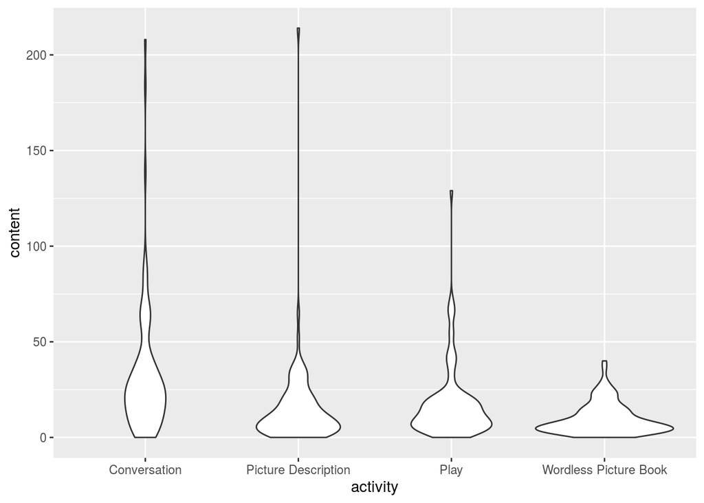

```r
ggplot(mazes, aes(x = activity, y = content)) +
  geom_violin()
```

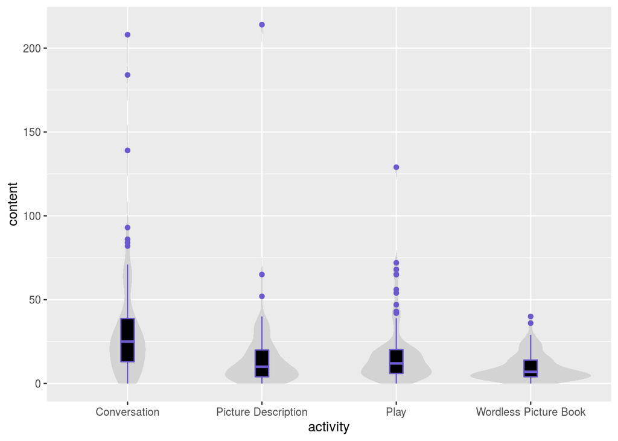

```r
ggplot(mazes, aes(x = activity, y = content)) +
  geom_violin(fill = "lightgray", color = NA) +
  geom_boxplot(width = .1, colour = "slateblue", fill = "black")
```

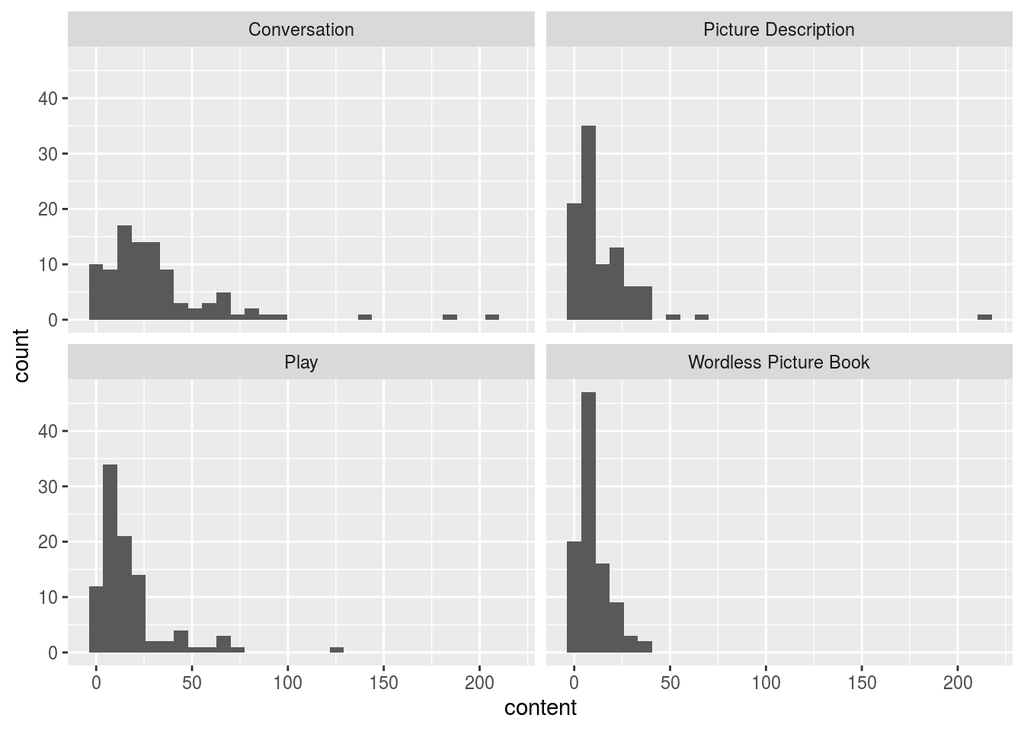

```r
ggplot(mazes, aes(content)) +
  geom_histogram() +
  facet_wrap(~activity)
```

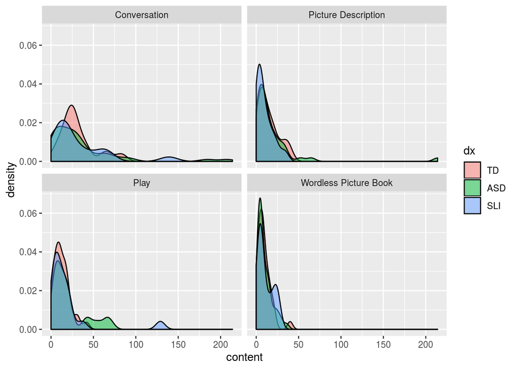

```r
ggplot(mazes, aes(content, fill = dx)) +
  geom_density(alpha = .5) +
  facet_wrap(~activity)
```